# HW3

Brandon Turner

3/10/2021

### 1) You walk into the “occasionally dishonest casino” with prior probabilities and likelihoods set to the values in slides 21-25 of lecture #4. (that is, a “loaded” die has a 10% chance of getting a 1-5 and a 50% chance of getting a 6 but 99% of the dice are fair). Make a graph of the posterior probability that you have picked up a loaded die as a function of the number of times you have rolled the die.

Probability of loaded dice = p(loaded) = 1/100 Probability of rolling 6 if loaded = p(roll 6| loaded) = 1/2 * 1/100 Probability of rolling 6 if loaded = p(roll 6| not loaded) = 1/6 * 99/100

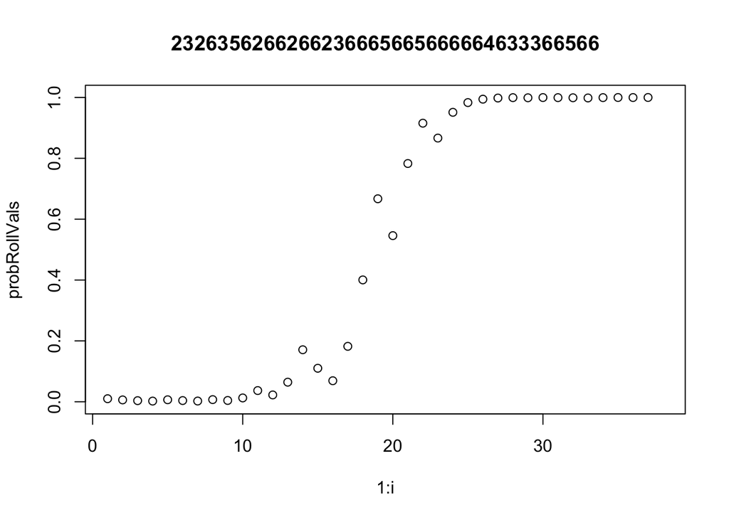

```r
# probs
p_loaded = c(0.01, 0.99)
likeli_givenLoaded = c(rep(1/10, 5), 1/2)
likeli_givenNotLoaded = c(rep(1/6, 6))

# oops i dont need a sim
loadedSim = c(2,3,2,6,3,5,6,2,6,6,2,6,6,2,3,6,6,6,5,6,6,5,6,6,6,6,6,4,6,3,3,3,6,6,5,6,6)

probRollVals <- vector();

titleStr <- ""
for( i in 1:length(loadedSim))
{
    probRollVals[i] <- p_loaded[1];

    denom <- p_loaded[1] * likeli_givenLoaded[loadedSim[i]] + p_loaded[2] * likeli_givenNotLoaded[loadedSim[i]];

    p_loaded[1] = p_loaded[1] * likeli_givenLoaded[loadedSim[i]] / denom;
    p_loaded[2] = p_loaded[2] * likeli_givenNotLoaded[loadedSim[i]] / denom;

    titleStr <- paste(titleStr,loadedSim[i],sep="")

}
plot(1:i,probRollVals, main = titleStr,ylim=c(0,1),xlim=c(1,length(loadedSim)+1))
```

#### 1B) How many times on average would you need to roll a loaded die to be 99.999% sure that it was loaded?

need to show: p(loaded | # of sixes in loaded sim)

```r
# check how many runs it takes until we are confidednt that it is loaded, 99%
for (i in 1:50){

  loadedGivenNumberOfSixes = (0.5**i * 0.01)/((0.5**i * 0.01) + (1/6**i * .99))
  print(paste(i, 'Sixes seen =', loadedGivenNumberOfSixes))

  if (loadedGivenNumberOfSixes > 0.9999){
    break
  }
}
```

```
## [1] "1 Sixes seen = 0.0294117647058824"
## [1] "2 Sixes seen = 0.0833333333333333"
## [1] "3 Sixes seen = 0.214285714285714"
## [1] "4 Sixes seen = 0.45"
## [1] "5 Sixes seen = 0.710526315789474"
## [1] "6 Sixes seen = 0.880434782608696"
## [1] "7 Sixes seen = 0.956692913385827"
## [1] "8 Sixes seen = 0.985135135135135"
## [1] "9 Sixes seen = 0.994995450409463"
## [1] "10 Sixes seen = 0.998326232501522"
## [1] "11 Sixes seen = 0.999441454250025"
## [1] "12 Sixes seen = 0.999813748730105"
## [1] "13 Sixes seen = 0.999937908533625"
```

### 2) You are consulting for a hospital. They have a diagnostic test for a disease with a known background prevalence of 0.1%. The test has the following properties: p(positive result | person has disease) = 0.91, p(negative result| person does not have disease) = 0.84. The cost of running the test one time is $1. The test can be repeated for each patient and the results of the test are independent of one another allowing for Bayesian updates. The test always yields a positive or negative result.The requirement of the hospital is that the test is repeated for each patient until a Bayesian posterior of at least 0.99999 is reached.

#### 2A)Run simulations for a patient with the disease. About how many times on average must the test be repeated to achieve the hospital’s requirements?

```r
hasDisease = c(0.001, 0.999)
positiveTestDisease = c(0.91, 0.09)
positiveTestNoDisease = c(0.16, 0.84)

# check how many runs it takes until we are confidednt that it is loaded, 99%
howManyTests = function(positiveTest, disease, positiveResults){
  for (i in 1:10000){

    result = (positiveTest[1]**i * disease[1])/((positiveTest[1]**i * disease[1]) + (positiveTest[2]**i * hasDisease[2]))

    if ( result > 0.9999 & positiveResults==TRUE){
      print(paste('It takes', i, 'tests for 99% sure of positive result'))
      break
    }
    if ( result < 1-0.9999 & positiveResults==FALSE){
      print(paste('It takes', i, 'tests for 99% sure of negative result'))
      break
    }

  }
}

howManyTests(positiveTestDisease, hasDisease, TRUE)
```

```
## [1] "It takes 7 tests for 99% sure of positive result"
```

#### 2B) Repeat the simulations for a patient without the disease. About how many times on average must the test be repeated to achieve the hospital’s requirements?

```r
howManyTests(positiveTestNoDisease, hasDisease, FALSE)
```

```
## [1] "It takes 2 tests for 99% sure of negative result"
```

#### 2C) The hospital plans to run the test on one million patients per year. At a cost of $1 per test, about how much should the hospital budget to run these tests? (That is to say, for a million patients, how many tests can the hospital anticipate running?)

The probability of a postive test is

```r
(0.91 * 0.001) + (0.999 * 0.16)
```

```
## [1] 0.16075
```

The probability of a ngeative test is

```r
(0.09 * 0.001) + (0.999 * 0.84)
```

```
## [1] 0.83925
```

So of 1,000,000 people we E(positve tests) = 160,750 , and E(negative tests) = 839,250

If it takes 7 tests to verify positve E(cost of positive) = $1,125,250 , and 2 test to verify negative E(cost of negative) = $1,678,500

So the hosplital can expect to run 2,803,750 tests.

### 3) Another manufacturer approaches the hospital with an improved, but more expensive, test with the following properties: p(positive result | person has disease) = 0.96, p(negative result| person does not have disease) = 0.95

#### 3A) With this test, how many times on average must the test be repeated to achieve the hospital’s requirements for patients with and without the disease?

```r
hasDisease = c(0.001, 0.999)
positiveTestDisease = c(0.96, 0.04)
positiveTestNoDisease = c(0.05, 0.95)

# check how many runs it takes until we are confidednt that it is loaded, 99%
howManyTests = function(positiveTest, disease, positiveResults){
  for (i in 1:10000){

    result = (positiveTest[1]**i * disease[1])/((positiveTest[1]**i * disease[1]) + (positiveTest[2]**i * hasDisease[2]))

    if ( result > 0.9999 & positiveResults==TRUE){
      print(paste('It takes', i, 'tests for 99% sure of positive result'))
      break
    }
    if ( result < 1-0.9999 & positiveResults==FALSE){
      print(paste('It takes', i, 'tests for 99% sure of negative result'))
      break
    }

  }
}

howManyTests(positiveTestDisease, hasDisease, TRUE)
```

```
## [1] "It takes 6 tests for 99% sure of positive result"
```

```r
howManyTests(positiveTestNoDisease, hasDisease, FALSE)
```

```
## [1] "It takes 1 tests for 99% sure of negative result"
```

#### 3B) Considering only the cost of the test, and assuming the hospital will screen one million patients with a background prevalence of 0.1%, at about what price point for running the test one time will the hospital save money by switching to the new test?

The probability of a postive test is

```r
# probability of pos and neg test
p_positiveTest = (0.96 * 0.001) + (0.999 * 0.05)
p_negativeTest = (0.04 * 0.001) + (0.999 * 0.95)

# how many tests will you need
ex_pos = p_positiveTest * 1000000
ex_neg = p_negativeTest * 1000000

# six tests needed for a positve confirmation
testsNeeded = (ex_pos * 6) + (ex_neg)

# divided the number of tests needed for the old test by the new
print(2803750/testsNeeded)
```

```
## [1] 2.234865
```